# Interactive Image Design

Eniola Awe

2026-09-24

**Functionality**

For this application I would want it to have a portrait orientation with two single buttons in the middle of the page: Upload Image and Enter k value. For the upload image button there will be a page that shows the user how they would like to upload their desired image. They can upload their image in three ways: browsing their device photos, importing an image url, or choosing an image under their files/documents. For the second button, the user can enter any k value they want. If the k value is invalid (contains special characters/letters/out of bound number) they will be presented with an error message. Once all information is entered, a new page will be shown with both images in the middle. On the left side, the user will see their original image labeled Original. On the right side, the user will see their k-valued image labeled ‘k = (whatever value they enter). There will be a button in the middle-bottom of the page asking the user if they want to upload a new image. If this button is clicked the user will be taken back to the home page.

**Aesthetics**

The background of the page will be white, the button colors will be dark blue and the text color for the button will be white. Once the button(s) are clicked the color will change to a lighter blue. For the next page it will be the same colors for both background and buttons, however, for the ‘Upload a new image’ will be gold.

**Image Design**

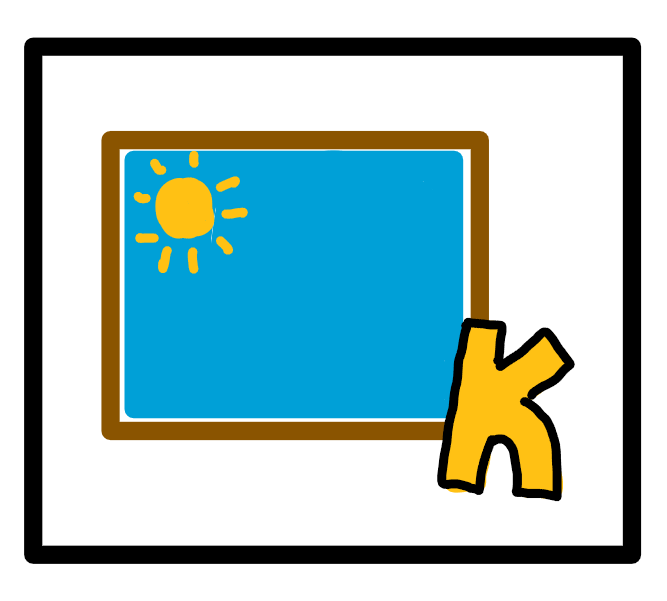